# Git install on Windows

Author

Ed123 Pal

## 1 Introduction

This tutorial instructs how to install Git on a Windows computer.

After Git is installed, you’ll see how to explore what’s been installed, how to add Git to the PATH environment variable and then do a quick verification that Git is working.

## 3 Download Git Software

### 3.1 Git website

Go to the [Git website](https://git-scm.com/).

Click on Download for Windows.

[figure not shown]

### 3.2 Start download

Click on the 64-bit Git for Windows Setup (assuming you have a 64-bit computer).

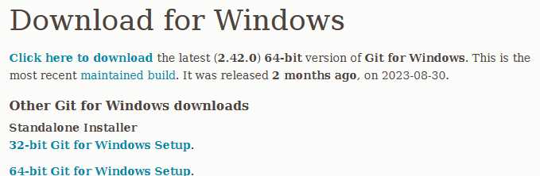

After the download completes, look in the Downloads folder to find the zipped file that contains the self-extracting Git installation file.

[figure not shown]

**Note**

The numbers shown on the downloaded file will likely be higher than what’s seen in the screenshot above because there will likely be a newer version of Git available when you are reading this tutorial.

## 4 Install Git

### 4.1 Downloads folder

See the installation file in the Download folder.

[figure not shown]

### 4.2 Start install

Double-click on the self-extracting Git installation file to start the installation wizard running.

You may first see a window asking for permission to change your device. If so, click Yes.

### 4.3 Install details

**Note**

You’ll accept the defaults shown on most of the installation windows, but in some cases you will be directed to make a change before clicking Next.

Click Next.

[figure not shown]

Click Next.

[figure not shown]

Click Next.

[figure not shown]

Click Next.

[figure not shown]

The screenshot shown below indicates that Git will use the Vim editor as its default editor.

[figure not shown]

Select either Windows Notepad or Notepad++ from the drop down menu.

Click Next.

[figure not shown]

**Note**

This tutorial assumes that you’ve previously installed Notepad++. It’s one the most popular open-source text editors used by developers worldwide.

The screenshot shown below indicates that Git will use the branch name “master” for the initial branch on newly created repositories. GitHub as well as most developers have decided to use “main” instead of “master”.

[figure not shown]

Click the radio button to Override the default and use “main”.

Click Next.

[figure not shown]

Click Next.

[figure not shown]

Click Next.

[figure not shown]

Click Next.

[figure not shown]

Click Next.

[figure not shown]

Click Next.

[figure not shown]

Click Next.

[figure not shown]

Click Next.

[figure not shown]

Click Next.

[figure not shown]

[figure not shown]

[figure not shown]

[figure not shown]

## 5 Verify install

### 5.1 Path variable

Verify the Git installation process added Git to the Path variable. If not, do so.

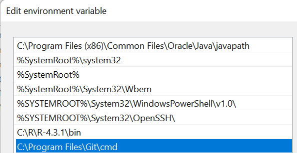

### 5.2 Git version

Open a Command Prompt window and check the Git version. If the Git version command returns the Git version then it’s likely the Git software is working correctly.

[figure not shown]

## 6 Wrap Up

### 6.1 Congratulations!

You’ve completed this tutorial and should now be able to install Git on your computer and verify that it is working.

### 6.2 What’s next?

Install Git.

You’ll then be ready for the Git post-install tutorial.